# Final Project

**Data Description**

The dataset used in this portfolio was sourced from Kaggle and encompasses all recorded natural disasters worldwide between 1900 and 2021. It includes detailed information such as disaster type, country and region of occurrence, total deaths, injuries, people affected, and estimated economic damages. The purpose of compiling this dataset is to analyze the impact and trends of natural disasters over time, offering insights into how the increasing frequency and severity of such events may be linked to the climate crisis. This analysis can help inform policy decisions, preparedness strategies, and climate resilience planning.

Link: [Data Source](https://www.kaggle.com/datasets/brsdincer/all-natural-disasters-19002021-eosdis/data)

**Data Cleaning**

*Research Question #1* For the first part of the data cleaning, I needed to focus on the end goal of Research Question #1. Because the first question was, “Does the region where a disaster occurred affect the amount of fatalities?”, I started with looking over the original, raw dataset to select the variables (Region, Origin, Total Deaths, Total Damages (’000 US$)) that would be useful in the final visualization. After the first cleaning, I was able to add this new dataset into a data clean folder to save for later. After the initial clean, I first, calculated the average number of deaths (death_avg) for each region by grouping the cleaned dataset (ResearchQ1_clean) by Region and taking the mean of the Total Deaths column. Then I did a similar code chunk as the last but averaged the Total Damages within the same dataset that was used for the previous chunk. Lastly, I used a left join the average damage dataset to the death average dataset by the matching regions to complete the dataset that would be used to create the visualization for Research Question #1.

*Research Question #2* For the second part of the data cleaning, I need to focus on the end goal of Research Question #2. Because the first question was, “How does the type of disaster influence the total number of deaths per Continent?”, I once again originated to the raw dataset to select the variables (Disaster Type, Country, Region, Continent,Total Deaths, No Injured, Total Affected, Total Damages (’000 US$)) that is useful for the second final visualization. After cleaning and selecting the necessary variables, I started to filter and remove the unnecessary columns where there is missing data within the columns that use integers (Deaths, Injured, Affected, Damages). I was also able to filter and remove the unnecessary columns where there is missing data within the columns that use characters (Disaster Type, Continent). Then I completed the data cleaning by adding this new cleaner dataset back into the clean data folder.

**Visualization 1**

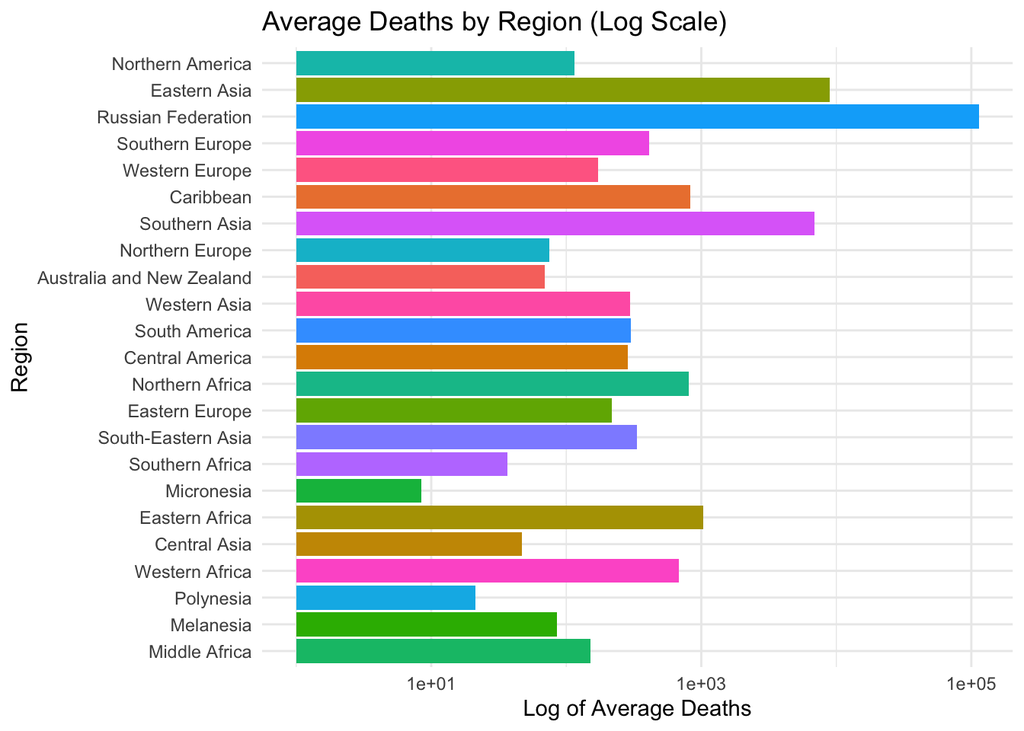

*Figure 1.* Average number of deaths by region, displayed on a logarithmic scale. The Russian Federation and Eastern Asia exhibit the highest averages.

**Visualization 2**

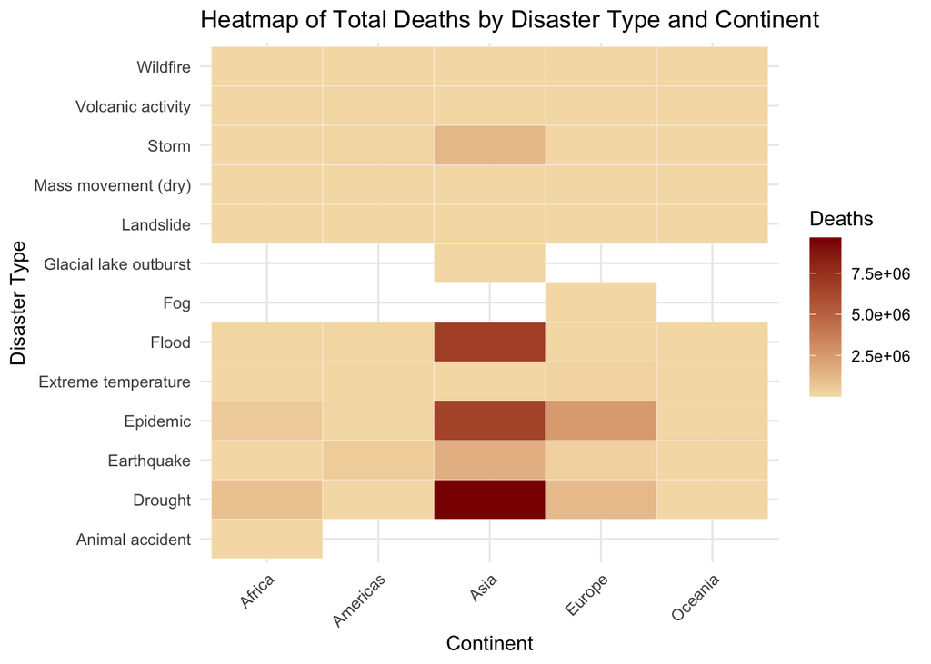